# HW 2: Предсказание отклика

Бобриков Дмитрий, ddbobrikov

## Задача

Для предсказания отлика необходимо определить переменные, которые имеют взаимосвязь с откликом, при помощи статистических тестов, чтобы в дальнейшем построить дерево предсказания, которое покажет нам, с какой вероятностью отклик будет произведен еще раз.

### Загрузка данных и преобразование

Датасет был очищен от NA (они составили статистически незначительную часть датасета, поэтому их без зазрения совести можно не использовать), также была удалена колонка с ID, так как она не важна для решения поставленной задачи. Почистили датасет от NA

### Исследовательские вопросы и тесты

1. Какая взаимосвязь между числом дней, прошедших с последней покупки, и откликом у клиента?

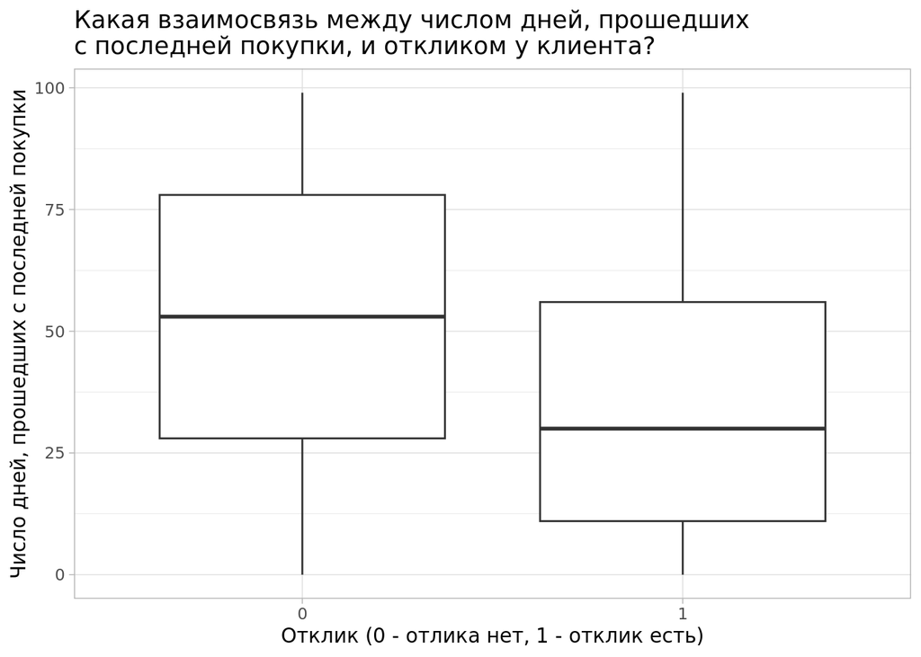

Вывод: Статистический тест (в этом случае t-test) показал, взаимосвязь между числом дней, прошедших с последней покупки, и откликом у клиента следующая: отклик был больше у тех клиентов, у которых количество дней с последней покупки было меньше. Маленький p-value (< 2.2*10^(-16)) подтверждает наличие этой взаимосвязи.

2. Какая взаимосвязь между количеством детей, включая подростков, и откликом у клиента?

```
##
##  Welch Two Sample t-test
##
## data:  Kidhome by Response
## t = 4.409, df = 640.06, p-value = 1.218e-05
## alternative hypothesis: true difference in means between group 0 and group 1 is not equal to 0
## 95 percent confidence interval:
##  0.0781873 0.2037610
## sample estimates:
## mean in group 0 mean in group 1
##       0.4833165       0.3423423
```

```
##
##  Welch Two Sample t-test
##
## data:  Teenhome by Response
## t = 7.4132, df = 631.45, p-value = 3.981e-13
## alternative hypothesis: true difference in means between group 0 and group 1 is not equal to 0
## 95 percent confidence interval:
##  0.1754605 0.3019168
## sample estimates:
## mean in group 0 mean in group 1
##       0.5449949       0.3063063
```

Вывод: Статистические тесты (в этом случае t-tests) показали, что взаимосвязь между количеством детей, включая подростков, и откликом у клиента есть, причем средние значения в этих тестах показали, что у тех клиентов, которые откликнулись, детей (и подростков тоже) в среднем меньше. Отсюда следует, что отклик больше у тех, у кого детей и подростков меньше.

3. Какая взаимосвязь между статусом брака и откликом клиента?

```
##
##  Pearson's Chi-squared test
##
## data:  marketing$Marital_Status and marketing$Response
## X-squared = 53.939, df = 7, p-value = 2.418e-09
```

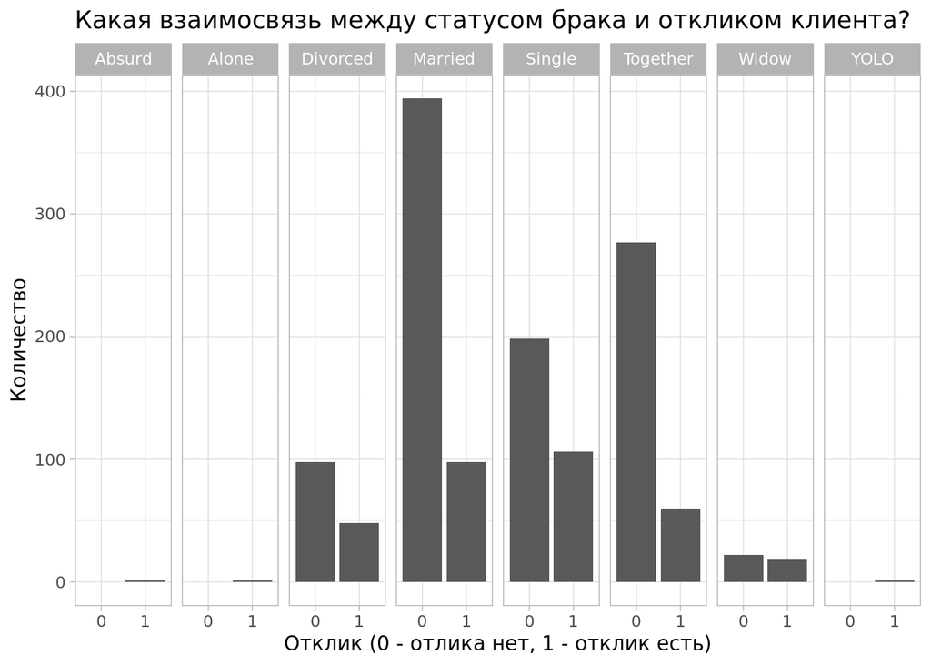

Вывод: Статистический тест (в этом случае хи квадрат тест) показал, что взаимосвязь между статусом брака и откликом клиента есть (это доказывает маленький p-value = 2.418*10^(-9)), причем, судя по графику, мы можем сказать, что больше всего влияют клиенты со статусами женат/замужем, вместе, один/одна.

### Предсказание отклика на кампанию

Построим дерево на основе предыдущих шагов.

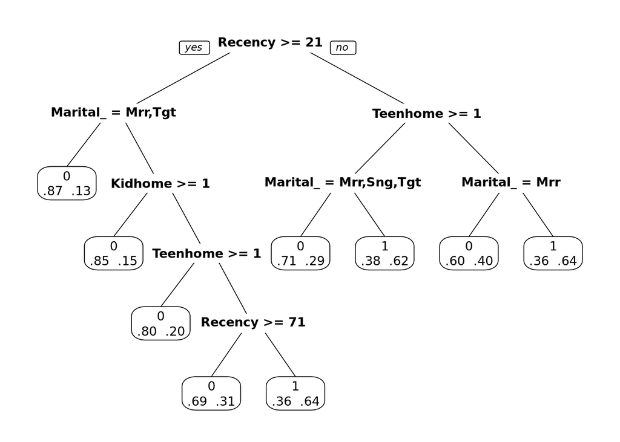

###Выводы по дереву Построенное дерево доказало, что вышеперечисленные переменные действительно влияют на вероятность отклика клиентом, а значит, задача выполнена. Осталось оценить качество выполненного предсказания.

###Оценка качества предсказания

Точность (accuraccy) показала результат качества дерева величиной 0.7967864, что является хорошим результатом.

###Описание предсказаний для разных групп клиентов

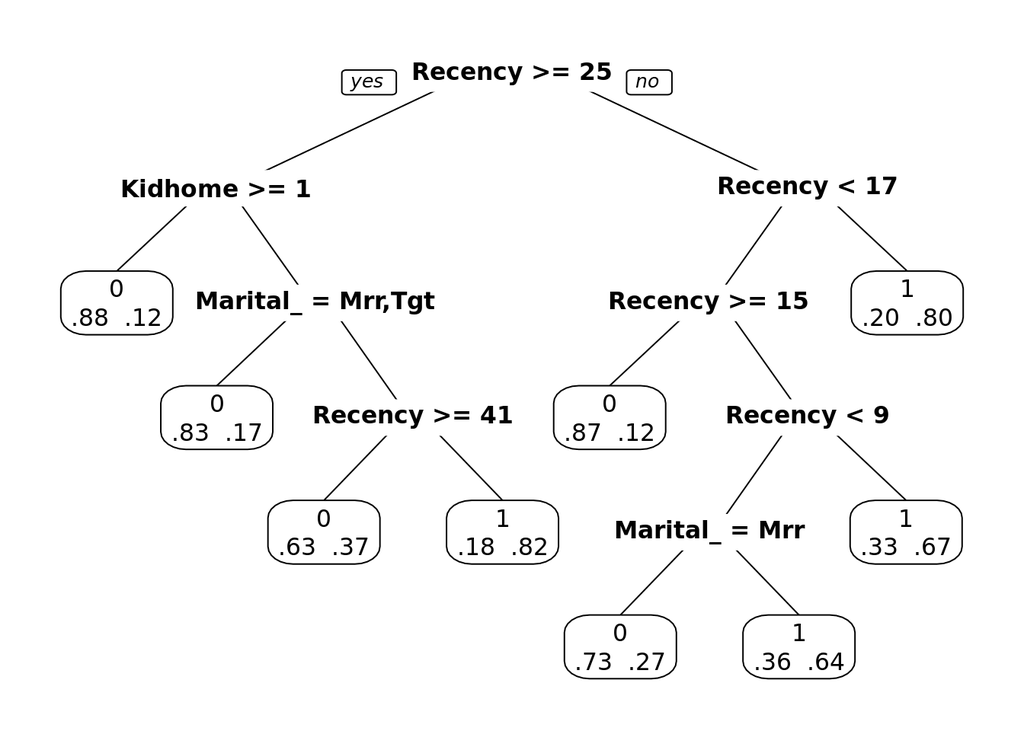

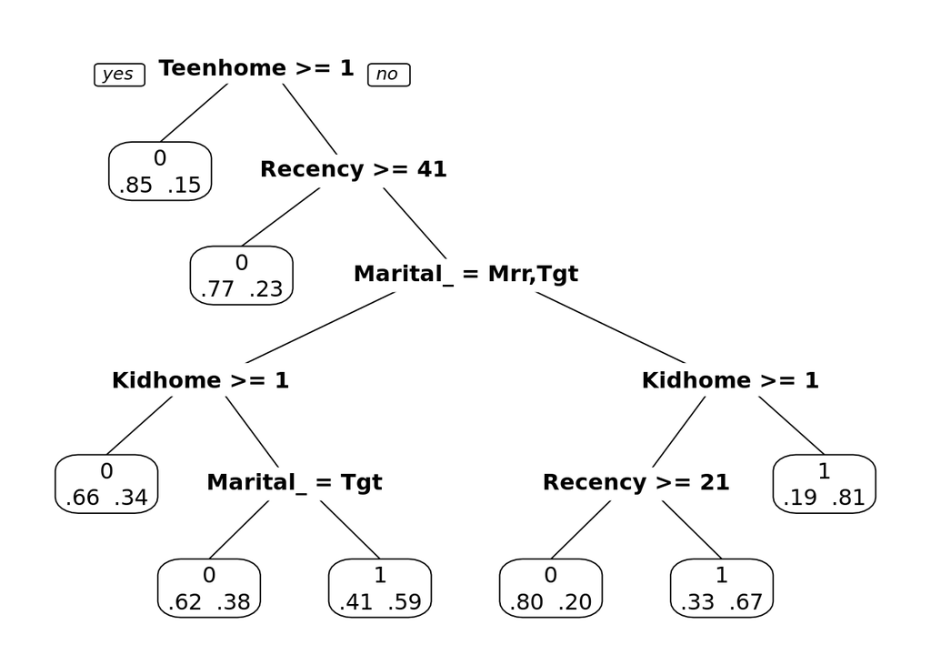

Построим деревья для клиентов, родившихся после 1980, и для тех, кто родился до 1980, включая этот год. Заметим, что дерево для клиентов, родившихся после 1980, предсказывает лучше, так как точность составила на 1 процент больше, чем у второй группы клиентов.

## Общие выводы

Данная работа выполнила свою задачу, а именно составила предсказательные модели в виде деревьев, основываясь на статистических тестах. Были успешно выведены взаимосвязи отклика клиентов с такими переменными, как количество детей и подростков, количество дней с прошлой покупки и статусами брака.